# ggsolvencyii

Marco van Zanden

2018-11-16

[figure not shown]

The goal of ggsolvencyii is to provide ‘ggplot2’-geom’s to show the composition of the Solvency (II) Capital Requirement (SCR) from (diversified) risks and subrisks, whether for standard formula (SF) or (partial) intern models (IM/PIM).

## Installation

You can install ggsolvencyii from Github:

```r
# install.packages("devtools")
devtools::install_github("vanzanden/ggsolvencyii")
# or from the binary in github.com/vanzanden/ggsolvencyii/binaries/windows
```

## Vignettes

The following vignettes are available or will be available soon check https://github.com/vanzanden/ggsolvencyii/tree/master/vignettes

- ggsolvencyii (this vignette)
- geom_sii_risksurface (placeholder)
- geom_sii_riskoutline (placeholder)
- geom_sii_riskconnection (placeholder)
- plotdetails (placeholder)
- showcase
- coding_overview (placeholder)

## example

ggsolvencyii builds on ggplot-functionality and provides three geom’s: * `geom_sii_risksurface` * `geom_sii_riskoutline` * `geom_sii_riskconnection`

These were used to produce the following plot which for example could be used for an ORSA report.

The commented code is shown in vignette “showcase”.

```
#> scaling is based on inputvalue (maxscrvalue) of 25.7433642812936
#> scaling is based on a max (level= 1) value of 25.7433642812936
#> scaling is based on a max (level= 1) value of 25.7433642812936
#> scaling is based on a max (level= 1) value of 25.7433642812936
```

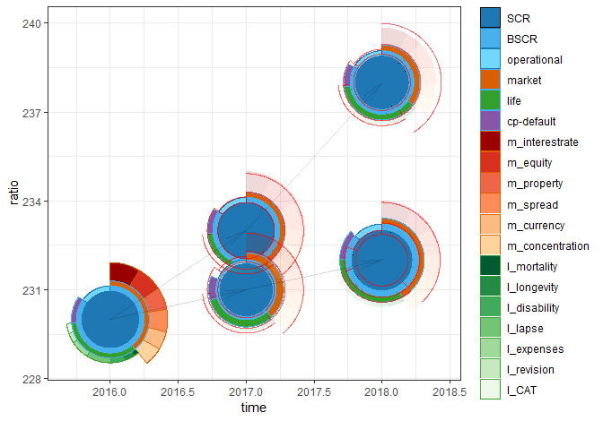

The total surface (to the centerpoint of each circle) of the outer segments show the size of undiversified risks. Diversification is made visible by the difference between the risk segment and the next segment nearer to the center of the plot. The red (out)lines are displayed for comparison with the previous SCR buildup.

For troubleshooting `sii_debug` provides an overview of present risk descriptions and levels in the data and supporting tables.

## Baseplot and options

### base

An life insurer reports its solvency ratio following Standard Formula rules, with English names for all risks. It has a set of risks, diversification effects, and accumulations to the SCR for the current situation (‘id’=1) and three three-year ORSA scenarios (‘id’ is 2-4, 5-7, 8-10). The results are stored in a datafile of which the first lines and columns are shown here:

|  | id | time | comparewithid | ratio | SCR | Adjustment-LACDT | BSCR | BSCR_div |
| --- | --- | --- | --- | --- | --- | --- | --- | --- |
| 1 | 1 | 2016 | NA | 230 | 23.00000 | -10.000000 | 28.00000 | -9.000000 |
| 4 | 2 | 2017 | 1 | 233 | 23.14993 | -9.158458 | 27.30838 | -9.135998 |
| 7 | 3 | 2018 | 2 | 238 | 19.99461 | -9.435391 | 24.43000 | -8.402552 |

Variable sii_z_ex1_data is the tidyverse representation of the dataset above (the first lines for ‘id’ = 1, 2 or 3 are shown).

|  | time | ratio | description | value | id | comparewithid |
| --- | --- | --- | --- | --- | --- | --- |
| 1 | 2016 | 230 | SCR | 23.00000 | 1 | NA |
| 2 | 2017 | 233 | SCR | 23.14993 | 2 | 1 |
| 3 | 2018 | 238 | SCR | 19.99461 | 3 | 2 |
| 11 | 2016 | 230 | BSCR | 28.00000 | 1 | NA |
| 12 | 2017 | 233 | BSCR | 27.30838 | 2 | 1 |
| 13 | 2018 | 238 | BSCR | 24.43000 | 3 | 2 |
| 21 | 2016 | 230 | operational | 5.00000 | 1 | NA |
| 22 | 2017 | 233 | operational | 5.00000 | 2 | 1 |

Variables sii_x_fillcolors… and sii_x_edgecolors are named lists with colorcodes for each risk-description

|  | x |
| --- | --- |
| SCR | #1f78b4 |
| BSCR | #48b0eb |
| operational | #70d8ff |
| market | #d95f02 |
| health | #4a1486 |
| life | #33a02c |

The SCR composition of the current situation (id = 1) is shown below

```
#> scaling is based on a max (level= 1) value of 23
```

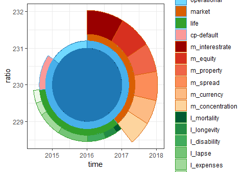

```r
ggplot() +
  geom_sii_risksurface(
    data = sii_z_ex1_data[sii_z_ex1_data$id == 1, ],
    mapping = aes(x = time,
                  y = ratio,
                  id = id,
                  value = value,
                  description = description,
                  color = description,
                  fill = description
                   ) ) +
theme_bw() +
scale_fill_manual(name = "Risks",values = sii_x_fillcolors_sf16_eng) +
scale_color_manual(name = "Risks",values = sii_x_edgecolors_sf16_eng)
```

### structure

`Geom_sii_risksurface` uses one default table for this plot `sii_structure_sf16_eng`. It defines each risks by indicating from which combined ‘child’-risks and diversification (suffix ‘d’) it is made up. Passing another structure table makes this geom usable for localisation or for internal models.

```r
head(sii_structure_sf16_eng, 13)
```

[output not shown]

### levelmax

To prevent cluttering of the legend it is possible to group the smallest items of a level by providing a levelmax-table in such a way that the indicated maximum items in that level is not exceded. the example is on another dataset `sii_z_ex2_data`, with only one SCR result.

```r
sii_levelmax_sf16_993
```

| level | levelmax |
| --- | --- |
| 1 | 99 |
| 2 | 99 |
| 3 | 99 |
| 4.01 | 3 |
| 4.02 | 3 |
| 4.03 | 3 |
| 4.04 | 3 |
| 5 | 3 |

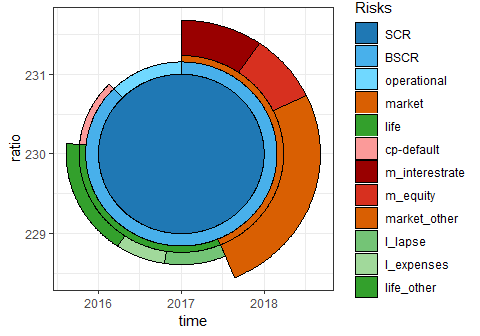

```r
ggplot() +
  geom_sii_risksurface(
    data = sii_z_ex2_data,
    mapping = aes(x = time, y = ratio, id = id, value = value,
                  description = description,
                  # color = description,
                  fill = description
                  ),
    color = "black",
    levelmax = sii_levelmax_sf16_993) +
theme_bw() +
scale_fill_manual(name = "Risks",values = sii_x_fillcolors_sf16_eng) # +
```

```r
# scale_color_manual(name = "Risks",values = sii_x_edgecolors_sf16_eng)
```

### Rotation and squared

Rotationdescription rotates the plot in such a way that the indicated item (can be on either level, i.e. works also on ‘life’ or ‘operational’) is plotted on just on the righthandside of ‘12 o’clock’. rotationdegrees is then added.

The option squared makes a square plot, with the surface of all segments still in proportion. The angle between the ’radial’lines of equal sized segments differ, based on the position of the segment.

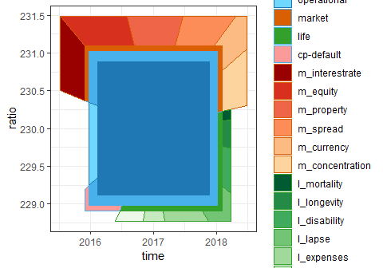

```
#> [1] "for id = 1 the description dependent rotation is : 325.945945945946 degrees"
```

```r
ggplot() +
  geom_sii_risksurface(
    data = sii_z_ex2_data,
    mapping = aes(x = time, y = ratio, id = id, value = value,
                           description = description,
                           fill = description, color = description),
                  squared = TRUE,
                  rotationdescription = 'm_equity',
                  rotationdegrees = -45) +
theme_bw() +
scale_fill_manual(name = "Risks",values = sii_x_fillcolors_sf16_eng) +
scale_color_manual(name = "Risks",values = sii_x_edgecolors_sf16_eng)
```

The second plot shows a comparison between a circle and square plot of the same data. Note that the radius of the SCR circle is smaller than the size of the SCR square !!

```
#> scaling is based on a max (level= 1) value of 30
#> scaling is based on a max (level= 1) value of 30
```

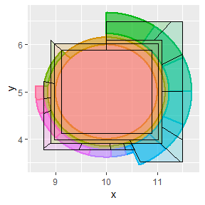

### Scaling

all SCR-buildups from a single call to `geom_sii_risksurface` or `geom_sii_riskoutline` plot are by default scaled in such a way that the largest SCR has a plotradius of one. When combining more calls, with several datasets a manual `maxscrvalue`-value can be given as a parameter. To prevent distortion, depending on the scale of x and y axis, `scalingx` and `scalingy` parameters are available.

### Plotdetails

The plotdetails table can be passed as a parameter to `geom_sii_risksurface` and `geom_sii_riskoutline`. It indicates whether to actual plot surfaces or outlinesegments (1 to 4) *after* the composition of the round (or squared) layout of segments. An example is the seperate plotting of inner and outer segments, with different transparancy in the showcase, or only plotting the outline of the SCR itself and the lowest risklevels. See the separate vignette for a detailed explanation.

## Outlines, comparewithid

If the optional aes `comparewithid` is passed to `geom_sii_riskoutline` a link is made between the x and y value of an ‘id’ and the SCR composition of that SCR buildup where `comparewithid` references to. This can be used to overlay the outline of one SCR over the surfaceplot of another. This for easy comparison between the two. See vignettes “geom_sii_riskoutline” and “geom_sii_riskconnection” for details